# Lab 3: Baseline Model — Simple Regression

- Show All Code
- Hide All Code
- View Source

CRISP-DM Phase 3 & 4 — Data Preparation & Modeling

Author

Prof. Dr. Jörg Schoder

Published

March 18, 2026

## 1 Learning Objectives and Overview

**NoteLearning Objectives**

- Ein einfaches OLS-Modell als **Benchmark** schätzen und interpretieren
- Koeffizienten als **bedingte Mittelwerte** verstehen — nicht als Kausalaussagen
- Das **Bestimmtheitsmaß R²** berechnen und korrekt interpretieren
- **Residuen** als Underperformance-Maß lesen und im Residualplot sehen
- Den **Omitted Variable Bias** (OVB) im Residualplot diagnostizieren

**Szenario:** In Lab 1 haben Sie die Carseats-Daten exploriert und festgestellt, dass `Price` negativ mit `Sales` korreliert. Jetzt bauen Sie das einfachste mögliche Regressionsmodell — das **Baseline-Modell** — und prüfen kritisch, was es kann und was nicht.

**TipZeitplanung**

⏱ **15 Minuten** — Pflichtaufgaben (A1–A3), Bonusaufgaben wenn Zeit bleibt.

## 2 Hintergrund: OLS und der bedingte Mittelwert

### 2.1 Die Grundidee der linearen Regression

OLS (Ordinary Least Squares) schätzt eine Gerade der Form:

$$\hat{y}_i = \hat\beta_0 + \hat\beta_1 \cdot x_i$$

wobei $\hat{y}_i$ den **bedingten Mittelwert** von $y$ gegeben $x_i$ approximiert:

$$\hat{y}_i \approx E[Y \mid X = x_i]$$

**ImportantRegression als Benchmark — nicht als Wahrheit**

Die Regressionsgerade ist **kein** Kausalmodell und **keine** exakte Vorhersage. Sie ist der **Marktstandard**: der Umsatz, den eine Filiale *im Durchschnitt* bei diesem Preis erzielen sollte.

Eine Filiale mit einem stark **negativen Residuum** verkauft weniger als der Markt erwartet — das ist das Underperformance-Signal das wir suchen.

> *“Regression does not give us truth. It gives us conditional averages — benchmarks against which to judge individual cases.”* — @taddy_business_2019, S. 32

### 2.2 Herleitung: Methode der kleinsten Quadrate

OLS wählt $\hat\beta_0$ und $\hat\beta_1$ so, dass die **Summe der quadrierten Residuen (SSR)** minimal wird:

$$\min_{\hat\beta_0,\, \hat\beta_1} \sum_{i=1}^{n} e_i^2 = \sum_{i=1}^{n}(y_i - \hat\beta_0 - \hat\beta_1 x_i)^2$$

Die Bedingungen erster Ordnung (partielle Ableitungen = 0) liefern analytische Lösungen:

$$\hat\beta_1 = \frac{s_{xy}}{s_x^2} = \frac{\sum_i(x_i - \bar{x})(y_i - \bar{y})}{\sum_i(x_i - \bar{x})^2}$$

$$\hat\beta_0 = \bar{y} - \hat\beta_1 \cdot \bar{x}$$

**Interpretation:**

- $\hat\beta_1$: Steigungskoeffizient — **marginaler Effekt** von $x$ auf $\hat{y}$. Pro Einheit mehr in $x$ ändert sich $\hat{y}$ um $\hat\beta_1$ Einheiten.
- $\hat\beta_0$: Achsenabschnitt (Intercept) — vorhergesagter Wert von $\hat{y}$ wenn $x = 0$.

### 2.3 Bestimmtheitsmaß R²

Die Gesamtstreuung (TSS) lässt sich in erklärte Streuung (ESS) und Reststreuung (SSR) zerlegen:

$$\underbrace{\sum_i(y_i - \bar{y})^2}_{\text{TSS}} = \underbrace{\sum_i(\hat{y}_i - \bar{y})^2}_{\text{ESS}} + \underbrace{\sum_i e_i^2}_{\text{SSR}}$$

Das Bestimmtheitsmaß misst den Anteil der erklärten Streuung:

$$R^2 = \frac{\text{ESS}}{\text{TSS}} = 1 - \frac{\text{SSR}}{\text{TSS}} \in [0, 1]$$

**NoteR² korrekt interpretieren**

$R^2 = 0.15$ bedeutet: **15% der Varianz in `Sales`** wird durch das Modell erklärt. Die restlichen 85% sind auf andere (nicht im Modell enthaltene) Faktoren zurückzuführen.

Ein niedriges $R^2$ ist **kein Fehler** — es zeigt an, dass wichtige Variablen fehlen. Das ist didaktisch wertvoll: es motiviert das **multiple Modell** mit ShelveLoc und Advertising.

## 3 Schritt 1: Baseline-Modell schätzen

### 3.1 Einfachregression Sales ~ Price

```r
library(moderndive)

# Modell fitten
mod_baseline <- tbl_carseats %>%
  lm(Sales ~ Price, data = .)

# Regressionstabelle
mod_baseline %>%
  get_regression_table() %>%
  gt() %>%
  fmt_number(columns = c(estimate, std_error, statistic,
                         p_value, lower_ci, upper_ci),
             decimals = 4) %>%
  tab_style(
    style     = cell_fill(color = "#fff8e1"),
    locations = cells_body(rows = term == "Price")
  ) %>%
  tab_options(table.font.size = "14px") %>%
  tab_footnote("Gelb = Steigungskoeffizient für Price")
```

| term | estimate | std_error | statistic | p_value | lower_ci | upper_ci |
| --- | --- | --- | --- | --- | --- | --- |
| intercept | 13.6420 | 0.6330 | 21.5580 | 0.0000 | 12.3980 | 14.8860 |
| Price | −0.0530 | 0.0050 | −9.9120 | 0.0000 | −0.0640 | −0.0430 |

Gelb = Steigungskoeffizient für Price

**NoteAlle Spalten der Regressionstabelle erklärt**

| Spalte | Bedeutung |
| --- | --- |
| `estimate` | Geschätzter Koeffizient $\hat\beta$ |
| `std_error` | Standardfehler — Streuung der Schätzung (→ PVA2) |
| `statistic` | t-Wert = estimate / std_error |
| `p_value` | Wahrscheinlichkeit unter $H_0: \beta = 0$ (→ PVA2) |
| `lower_ci` / `upper_ci` | 95%-Konfidenzintervall (→ PVA2) |

**Heute fokussieren wir auf `estimate`** — die Inferenz (Spalten 2–6) kommt in PVA2.

### 3.2 Modellgüte

**Code anzeigen**

```r
mod_baseline %>%
  get_regression_summaries() %>%
  select(r_squared, adj_r_squared, rmse, sigma, nobs) %>%
  gt() %>%
  fmt_number(columns = c(r_squared, adj_r_squared, rmse, sigma),
             decimals = 4) %>%
  tab_options(table.font.size = "14px")
```

| r_squared | adj_r_squared | rmse | sigma | nobs |
| --- | --- | --- | --- | --- |
| 0.1980 | 0.1960 | 2.5260 | 2.5320 | 400 |

**Caution A1: Koeffizienten interpretieren**

Schreiben Sie die Regressionsgleichung auf und interpretieren Sie die Koeffizienten:

$$\widehat{\text{Sales}} = \hat\beta_0 + \hat\beta_1 \cdot \text{Price}$$

1. **Intercept $\hat\beta_0$:** Was sagt dieser Wert inhaltlich? Ist er sinnvoll interpretierbar (Preis = 0)?
2. **Steigung $\hat\beta_1$:** Wie verändert sich der vorhergesagte Umsatz, wenn der Preis um 1 USD steigt? Um 10 USD?
3. **$R^2$:** Wie viel Prozent der Umsatzvarianz erklärt das Modell? Was bedeutet das für die Qualität des Modells?
4. **RMSE:** Was sagt der Root Mean Squared Error über die durchschnittliche Vorhersagegenauigkeit (in welchen Einheiten)?

### 3.3 Visualisierung: Regressionsgerade

**Code anzeigen**

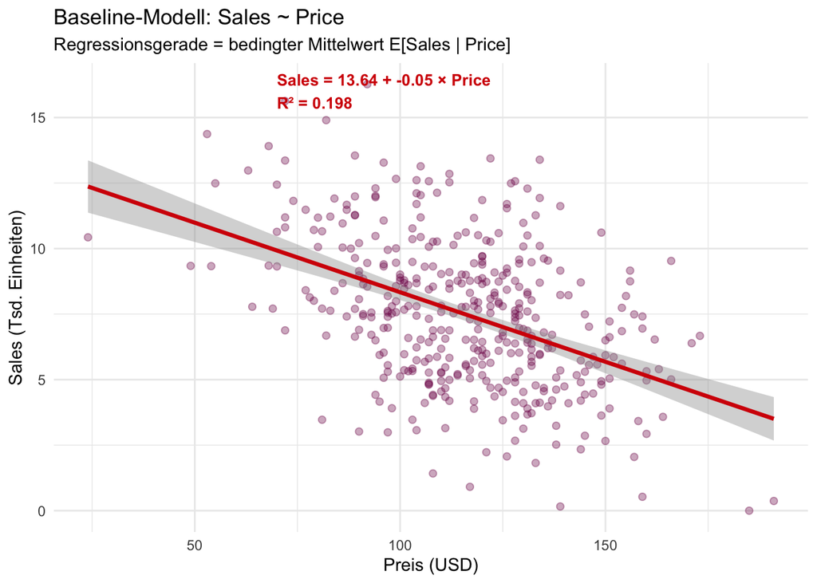

```r
tbl_carseats %>%
  ggplot(aes(x = Price, y = Sales)) +
  geom_point(alpha = 0.35, color = "#7d0a52", size = 1.8) +
  geom_smooth(method = "lm", color = "#D50006",
              se = TRUE, linewidth = 1.2) +
  annotate("text", x = 70, y = 16,
           label = paste0("Sales = ",
                          round(coef(mod_baseline)[1], 2), " + ",
                          round(coef(mod_baseline)[2], 2), " × Price\n",
                          "R² = ", round(summary(mod_baseline)$r.squared, 3)),
           color = "#D50006", size = 3.5, hjust = 0, fontface = "bold") +
  labs(
    title    = "Baseline-Modell: Sales ~ Price",
    subtitle = "Regressionsgerade = bedingter Mittelwert E[Sales | Price]",
    x = "Preis (USD)", y = "Sales (Tsd. Einheiten)"
  ) +
  theme_minimal(base_size = 11)
```

## 4 Schritt 2: Residualanalyse

### 4.1 Residuen berechnen und anzeigen

```r
reg_points <- mod_baseline %>%
  get_regression_points()

# Erste 10 Beobachtungen
reg_points %>%
  head(10) %>%
  gt() %>%
  fmt_number(columns = c(Sales, Price, Sales_hat, residual),
             decimals = 3) %>%
  tab_style(
    style     = cell_fill(color = "#fff0f0"),
    locations = cells_body(rows = residual < -2)
  ) %>%
  tab_style(
    style     = cell_fill(color = "#f0fff0"),
    locations = cells_body(rows = residual > 2)
  ) %>%
  tab_options(table.font.size = "13px") %>%
  tab_footnote("Rot = stark negatives Residuum (Underperformer) | Grün = stark positives (Outperformer)")
```

| ID | Sales | Price | Sales_hat | residual |
| --- | --- | --- | --- | --- |
| 1 | 9.500 | 120.000 | 7.273 | 2.227 |
| 2 | 11.220 | 83.000 | 9.237 | 1.983 |
| 3 | 10.060 | 80.000 | 9.396 | 0.664 |
| 4 | 7.400 | 97.000 | 8.494 | −1.094 |
| 5 | 4.150 | 128.000 | 6.849 | −2.699 |
| 6 | 10.810 | 72.000 | 9.821 | 0.989 |
| 7 | 6.630 | 108.000 | 7.910 | −1.280 |
| 8 | 11.850 | 120.000 | 7.273 | 4.577 |
| 9 | 6.540 | 124.000 | 7.061 | −0.521 |
| 10 | 4.690 | 124.000 | 7.061 | −2.371 |

Rot = stark negatives Residuum (Underperformer) | Grün = stark positives (Outperformer)

**NoteDas Residuum als Underperformance-Maß**

$$e_i = y_i - \hat{y}_i = \text{Sales}_i - \widehat{\text{Sales}}_i$$

- **$e_i < 0$:** Filiale verkauft **weniger** als der Preis-Benchmark erwarten würde → Underperformer
- **$e_i > 0$:** Filiale verkauft **mehr** als erwartet → Outperformer
- **$e_i \approx 0$:** Filiale liegt im Marktdurchschnitt

### 4.2 Residualplot

**Code anzeigen**

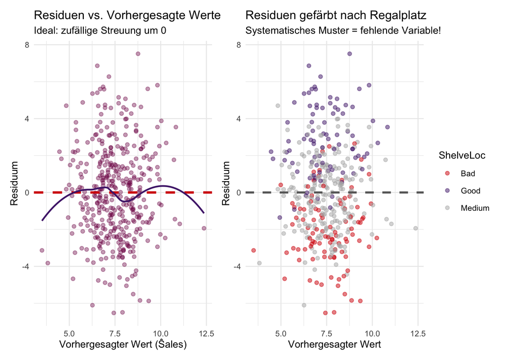

```r
pts <- augment(mod_baseline, data = tbl_carseats)

# Plot 1: Residuen vs. Fitted Values
p1 <- pts %>%
  ggplot(aes(x = .fitted, y = .resid)) +
  geom_point(alpha = 0.4, color = "#7d0a52", size = 1.5) +
  geom_hline(yintercept = 0, color = "#D50006",
             linewidth = 1.1, linetype = "dashed") +
  geom_smooth(method = "loess", color = "#502479",
              se = FALSE, linewidth = 0.8) +
  labs(title = "Residuen vs. Vorhergesagte Werte",
       subtitle = "Ideal: zufällige Streuung um 0",
       x = "Vorhergesagter Wert (Ŝales)", y = "Residuum") +
  theme_minimal(base_size = 10)

# Plot 2: Residuen gefärbt nach ShelveLoc
p2 <- pts %>%
  ggplot(aes(x = .fitted, y = .resid, color = ShelveLoc)) +
  geom_point(alpha = 0.5, size = 1.5) +
  geom_hline(yintercept = 0, color = "#686868",
             linewidth = 1, linetype = "dashed") +
  scale_color_manual(values = c("Bad"    = "#D50006",
                                "Medium" = "#b3b2b2",
                                "Good"   = "#502479")) +
  labs(title = "Residuen gefärbt nach Regalplatz",
       subtitle = "Systematisches Muster = fehlende Variable!",
       x = "Vorhergesagter Wert", y = "Residuum",
       color = "ShelveLoc") +
  theme_minimal(base_size = 10)

p1 + p2
```

**Caution A2: Residualplot interpretieren**

1. **Plot links:** Zeigt der Residualplot ein zufälliges Muster oder eine Systematik? Was würde ein idealer Residualplot aussehen?
2. **Plot rechts:** Beschreiben Sie das Muster nach ShelveLoc-Färbung.
   - Wo liegen die roten Punkte (Bad) tendenziell?
   - Wo liegen die lila Punkte (Good)?
   - Was sagt das über eine fehlende Variable im Modell?
3. **Omitted Variable Bias:** Wenn ein Confounder (ShelveLoc) sowohl mit dem Regressor (Price) als auch mit der Zielvariable (Sales) korreliert — in welche Richtung wird der Preiskoeffizient verzerrt?

```r
# Prüfen: Korreliert ShelveLoc mit Price?
tbl_carseats %>%
  group_by(ShelveLoc) %>%
  summarise(mean_price = mean(Price),
            mean_sales = mean(Sales))
```

## 5 Schritt 3: OVB-Diagnose und Log-Transformation

### 5.1 R² manuell berechnen

```r
ssq <- reg_points %>%
  summarise(
    TSS = sum((Sales - mean(Sales))^2),
    SSR = sum(residual^2),
    ESS = TSS - SSR,
    R2  = 1 - SSR / TSS
  )
ssq %>%
  gt() %>%
  fmt_number(columns = everything(), decimals = 2) %>%
  tab_options(table.font.size = "14px")
```

| TSS | SSR | ESS | R2 |
| --- | --- | --- | --- |
| 3,182.27 | 2,552.23 | 630.05 | 0.20 |

### 5.2 Vergleich: lineares vs. log-lineares Modell

**Code anzeigen**

```r
# Modell mit log(Sales)
tbl_carseats_log <- tbl_carseats %>%
                      filter(Sales > 0) %>% #Log(0) undefiniert -> nur positive Sales)
                      mutate(log_sales = log(Sales))


mod_log <- tbl_carseats_log %>%
  lm(log_sales ~ Price, data = .)

# Vergleich
tibble(
  Modell   = c("Sales ~ Price (linear)", "log(Sales) ~ Price (log-linear)"),
  R2       = c(summary(mod_baseline)$r.squared,
               summary(mod_log)$r.squared),
  `β_Price` = c(coef(mod_baseline)[2],
                coef(mod_log)[2]),
  Interpretation = c(
    "1 USD mehr → β̂ Tsd. Einheiten mehr Sales",
    "1 USD mehr → β̂ × 100% mehr log(Sales)"
  )
) %>%
  gt() %>%
  fmt_number(columns = c(R2, `β_Price`), decimals = 4) %>%
  tab_options(table.font.size = "13px")
```

| Modell | R2 | β_Price | Interpretation |
| --- | --- | --- | --- |
| Sales ~ Price (linear) | 0.1980 | −0.0531 | 1 USD mehr → β̂ Tsd. Einheiten mehr Sales |
| log(Sales) ~ Price (log-linear) | 0.1599 | −0.0084 | 1 USD mehr → β̂ × 100% mehr log(Sales) |

**NoteInterpretation des log-linearen Koeffizienten**

Im log-linearen Modell gilt für kleine $\hat\beta$:

$$\hat\beta_1 \approx \frac{\Delta \text{Sales\%}}{1 \text{ USD Preis}}$$

Exakt: $e^{\hat\beta_1} - 1 =$ prozentuale Veränderung von Sales pro 1 USD Preis.

```r
# Exakte prozentuale Veränderung
(exp(coef(mod_log)[2]) - 1) * 100
```

**Caution A3: Modellvergleich und OVB**

1. Vergleichen Sie $R^2$ beider Modelle. Verbessert die Log-Transformation die Modellanpassung?
2. **OVB-Formel:** Der Bias im Preiskoeffizient ergibt sich als:
   $$\hat\beta_{\text{Price, biased}} = \beta_{\text{Price}} + \underbrace{\beta_{\text{ShelveLoc}} \cdot \frac{\text{Cov(Price, ShelveLoc)}}{\text{Var(Price)}}}_{\text{Bias}}$$

   Prüfen Sie empirisch: Wie stark verändert sich $\hat\beta_{\text{Price}}$, wenn Sie ShelveLoc ins Modell aufnehmen?

```r
# Modell OHNE ShelveLoc
mod_ohne <- lm(Sales ~ Price, data = tbl_carseats)

# Modell MIT ShelveLoc
mod_mit  <- lm(Sales ~ Price + ShelveLoc, data = tbl_carseats)

# Vergleich der Preiskoeffizienten
coef(mod_ohne)["Price"]
coef(mod_mit)["Price"]
```

3. In welche Richtung ist der Koeffizient verzerrt? Ist das konsistent mit Ihrer Erwartung aus A2?

## 6 Bonusaufgaben

**Tip B1: Varianzzerlegung visualisieren**

Visualisieren Sie TSS, ESS und SSR für die ersten 20 Beobachtungen:

```r
first20 <- reg_points %>% slice(1:20) %>%
  mutate(
    ybar = mean(tbl_carseats$Sales),
    x_rank = row_number()
  )

ggplot(first20, aes(x = x_rank)) +
  # TSS: Abweichung vom Mittelwert
  geom_segment(aes(xend = x_rank, y = ybar, yend = Sales),
               color = "#b3b2b2", linewidth = 1) +
  # SSR: Residuen
  geom_segment(aes(xend = x_rank, y = Sales_hat, yend = Sales),
               color = "#D50006", linewidth = 1.2) +
  # ESS: erklärte Abweichung
  geom_segment(aes(xend = x_rank, y = ybar, yend = Sales_hat),
               color = "#502479", linewidth = 1.2) +
  geom_point(aes(y = Sales), color = "#7d0a52", size = 2) +
  geom_point(aes(y = Sales_hat), color = "#D50006", shape = 17, size = 2) +
  geom_hline(yintercept = mean(tbl_carseats$Sales),
             linetype = "dashed", color = "#686868") +
  labs(title = "Varianzzerlegung: TSS = ESS + SSR",
       subtitle = "Grau = TSS | Lila = ESS (erklärt) | Rot = SSR (Residuum)",
       x = "Beobachtung", y = "Sales") +
  theme_minimal()
```

**Tip B2: Bestimmtheitsmaß und Korrelation**

Zeigen Sie empirisch, dass im Fall der Einfachregression gilt:
$$R^2 = r_{x,y}^2$$

```r
r_xy <- cor(tbl_carseats$Price, tbl_carseats$Sales)
r_xy^2
summary(mod_baseline)$r.squared
```

Warum gilt diese Gleichheit **nur** bei der Einfachregression, nicht bei der multiplen Regression?

**Tip B3: Underperformer identifizieren**

Erstellen Sie eine erste Rangliste der Underperformer-Filialen auf Basis des Baseline-Modells:

```r
reg_points %>%
  arrange(residual) %>%
  head(10) %>%
  select(ID, Sales, Price, Sales_hat, residual) %>%
  gt() %>%
  fmt_number(columns = c(Sales, Sales_hat, residual), decimals = 2) %>%
  tab_style(
    style = cell_fill(color = "#fff0f0"),
    locations = cells_body(rows = residual < -3)
  )
```

Was haben die Top-Underperformer gemeinsam? Schauen Sie sich ihre ShelveLoc an.

## 7 Zusammenfassung

| Kriterium | Baseline (Sales ~ Price) | Erwartung mit ShelveLoc |
| --- | --- | --- |
| R² | 0.198 | ~0.50 (deutlich besser) |
| β_Price | -0.053 USD/Tsd. | Verändert sich durch OVB-Korrektur |
| Residualplot | Systematisches Muster (ShelveLoc) | Zufällige Streuung um 0 |
| Verwendbarkeit | Zu ungenau für Entscheidungen | Bessere Benchmark-Qualität |
| Hauptproblem | Omitted Variable Bias durch ShelveLoc | Wird durch multiple Regression gelöst |

**ImportantKernbotschaften dieses Labs**

1. **Regression = bedingter Mittelwert** — kein Kausalmodell, sondern ein Benchmark.
2. **R² = 0.2** — der Preis allein erklärt nur einen kleinen Teil der Umsatzvarianz. Das ist keine Schwäche des Verfahrens, sondern ein Signal: wichtige Variablen fehlen.
3. **Residualplot diagnostiziert OVB** — das systematische ShelveLoc-Muster zeigt, dass der Preiskoeffizient durch eine fehlende Variable verzerrt ist.
4. **Log-Transformation** verbessert die Modellannahmen bei rechtsschiefen Zielvariablen und macht Koeffizienten als Elastizitäten interpretierbar.

**NoteÜberleitung zur Live-Demo**

In der **Live-Demo** zeigt der Dozent, was passiert wenn wir `ShelveLoc` und `Advertising` ins Modell aufnehmen: